# SDC spatial utility measures

We use pre-computed raster maps from `02_sdcSpatial_DE.R`, see [GitHub repo](https://github.com/mamoeh/sdcSpatialExperiment_DE?organization=mamoeh&organization=mamoeh).

```r
library(sdcSpatial)
library(SpatialKWD)
library(raster)
library(viridis)
load("sdcRasters_SHARE.RData")
load("pop_data_DE_500m_SHARE.RData")

pal <- rev(viridis(10))
```

First, we check for mass mismatch:

```r
true_mass <- sum(getValues(pop_ras$value$count),     na.rm = TRUE)
mass_rm   <- sum(getValues(pop_ras_rm$value$count),  na.rm = TRUE)
mass_qt1  <- sum(getValues(pop_ras_qt1$value$count), na.rm = TRUE)
mass_qt2  <- sum(getValues(pop_ras_qt2$value$count), na.rm = TRUE)
mass_sm   <- sum(getValues(pop_ras_sm$value$count),  na.rm = TRUE)

mismatch <- as.integer(c(true_mass, mass_rm, mass_qt1, mass_qt2, mass_sm))
names(mismatch) <- c("true", "removal", "quadtree I", "quadtree II", "smoothing")
rbind(mismatch, mismatch - true_mass)
```

```
##              true  removal quadtree I quadtree II smoothing
## mismatch 80324282 80113414   80324282    80324282  80324264
##                 0  -210868          0           0       -18
```

## Mass mismatch - smoothing

We lose mass from smoothing, but only a little. We can try again with a map that has padding around the borders. How much padding is needed?

`sdcSpatial::protect_smooth` calls `sdcSpatial::smooth_raster`, which in turn calls `raster::focalWeight` to make a smoothing weight matrix. The default Gaussian smoother has width / height of 3 times bandwidth on each side of the focal area. In other words, we need to add a border padding that is 3 times (bandwidth / cell width).

For instance, if we have a cell size of 100m by 100m and we use a smoothing bandwidth of 500m, we need 3 times (500m / 100m) = 15 cells padding. If we use the smallest smoothing bandwidth (= cell size), we always have a padding of 3.

```r
ras <- raster::disaggregate(pop_ras$value, fact = 5)
res(ras)
```

```
## [1] 100 100
```

```r
w1 <- raster::focalWeight(ras, d = 500, type = "Gauss")
(nrow(w1) - 1) / 2
```

```
## [1] 15
```

```r
res(pop_ras$value)
```

```
## [1] 500 500
```

```r
w2 <- raster::focalWeight(pop_ras$value, d = res(pop_ras$value)[1], type = "Gauss")
(nrow(w2) - 1) / 2
```

```
## [1] 3
```

If the map is originally not rectangular, but rectangularized by sdcSpatial, there is already mostly a ‘natural’ padding area. For the edge cases, we can rebuild the sdc_raster with an enlarged border:

```r
cwidth <- 500
bwidth <- 500
pad <- 3*(bwidth / cwidth)

r_pad <- raster(xmn = extnd[1] - (pad * cwidth), xmx = extnd[2] + (pad * cwidth),
                ymn = extnd[3] - (pad * cwidth), ymx = extnd[4] + (pad * cwidth),
                res = cwidth,
                crs = CRS("+init=epsg:3035"))

pop_ras_pad <- sdc_raster(as.matrix(pop_grid[, c("x_mp", "y_mp")]),
                             variable  = 1,
                             r         = r_pad,
                             min_count = 5,
                             max_risk  = 1.0)

ras_dim <- rbind(c(pop_ras$value@nrows, pop_ras$value@ncols),
                 c(pop_ras_pad$value@nrows, pop_ras_pad$value@ncols))
colnames(ras_dim) <- c("nrow", "ncol")
rownames(ras_dim) <- c("no pad", "padded")
ras_dim
```

```
##        nrow ncol
## no pad 1735 1284
## padded 1741 1290
```

Now, we re-do the smoothing and compare mass mismatch:

```r
pop_ras_sm_pad <- protect_smooth(pop_ras_pad, bw = bwidth)

mass_sm_pad <- sum(getValues(pop_ras_sm_pad$value$count), na.rm = TRUE)
mismatch_sm <- as.integer(c(true_mass, mass_sm, mass_sm_pad))
names(mismatch_sm) <- c("true", "smoothing", "smoothing (with pad)")
rbind(mismatch_sm, mismatch_sm - true_mass)
```

```
##                 true smoothing smoothing (with pad)
## mismatch_sm 80324282  80324264             80324282
##                    0       -18                    0
```

A smaller example for real-time calculation:

```r
data("dwellings")

rd <- raster(xmn = 149400, xmx = 161600, ymn = 457800, ymx = 470200, res = 200)

dwell <- sdc_raster(cbind(dwellings$x, dwellings$y), variable = 1, r = rd,
                    max_risk = 1.0, min_count = 10)

bw <- 400
pd <- (bw / 200) * 3

rdp <- raster::extend(rd, c(pd, pd))
dwell_pad <- sdc_raster(cbind(dwellings$x, dwellings$y), variable = 1, r = rdp)

dwell_sm_vanilla <- protect_smooth(dwell, bw = bw)
dwell_sm_padded  <- protect_smooth(dwell_pad, bw = bw)

mm <- c(sum(getValues(dwell$value$count),            na.rm = TRUE),
        sum(getValues(dwell_sm_vanilla$value$count), na.rm = TRUE),
        sum(getValues(dwell_sm_padded$value$count),  na.rm = TRUE))
names(mm) <- c("true", "smooth (vanilla)", "smooth (pad)")
rbind(mm, mm - mm[1])
```

```
##     true smooth (vanilla) smooth (pad)
## mm 90603        89558.303        90603
##        0        -1044.697            0
```

How does the mismatch influence KWD?

```r
getKWD <- function(x, x_orig, ...) {

  # need to also pad ground truth for comparability
  if (extent(x) > extent(x_orig)) {
    x_orig <- extend(x_orig, extent(x))
  }

  # get grid & weights
  xy <- raster::xyFromCell(x, 1:ncell(x))
  v_x <- getValues(x)
  v_o <- getValues(x_orig)

  # set NAs to 0
  v_x[is.na(v_x)] <- 0
  v_o[is.na(v_o)] <- 0

  kwd <- SpatialKWD::compareOneToOne(Coordinates = xy,
                                     Weights = cbind(v_o, v_x), ...)
  kwd
}

kwd_vanilla <- getKWD(dwell_sm_vanilla$value$count, dwell$value$count)
```

```
## CompareOneToOne, Solution method: APPROX
## WARNING: the Xs input coordinates are not consecutives integers.
## WARNING: the Ys input coordinates are not consecutives integers.
## INFO: Recoding the input coordinates to consecutive integers.
## INFO: change <timelimit> to 14400.000000
## INFO: change <verbosity> to silent
## INFO: change <opt_tolerance> to 0.000001
```

```r
kwd_padded  <- getKWD(dwell_sm_padded$value$count,  dwell$value$count)
```

```
## CompareOneToOne, Solution method: APPROX
## WARNING: the Xs input coordinates are not consecutives integers.
## WARNING: the Ys input coordinates are not consecutives integers.
## INFO: Recoding the input coordinates to consecutive integers.
## INFO: change <timelimit> to 14400.000000
## INFO: change <verbosity> to silent
## INFO: change <opt_tolerance> to 0.000001
```

```r
kwd_sm <- c(kwd_vanilla$distance, kwd_padded$distance)
names(kwd_sm) <- c("smooth (vanilla)", "smooth (pad)")
kwd_sm
```

```
## smooth (vanilla)     smooth (pad)
##        0.7891575        0.7138958
```

## Mass mismatch - removal

Mismatching mass after removal is a given:

```r
dwell_rm <- remove_sensitive(dwell)

mm_rm <- c(sum(getValues(dwell$value$count), na.rm = TRUE),
           sum(getValues(dwell_rm$value$count), na.rm = TRUE))
names(mm_rm) <- c("true", "removal")
rbind(mm_rm, mm_rm - mm_rm[1])
```

```
##        true removal
## mm_rm 90603   88530
##           0   -2073
```

A possible manual solution to the problem: add the missing mass to a number of bins, located centrally in the map quadrants:

```r
mis <- -(mm_rm - mm_rm[1])[2]

b_x <- floor(dwell$value@ncols / 4)
b_y <- floor(dwell$value@nrows / 4)
bp <- rbind(c(b_x, b_x, 3*b_x, 3*b_x),
            c(b_y, 3*b_y, b_y, 3*b_y))

dwell_rm_bal <- dwell_rm

dwell_rm_bal$value$count[bp[1, 1], bp[2, 1]] <- mis/4
dwell_rm_bal$value$count[bp[1, 2], bp[2, 2]] <- mis/4
dwell_rm_bal$value$count[bp[1, 3], bp[2, 3]] <- mis/4
dwell_rm_bal$value$count[bp[1, 4], bp[2, 4]] <- mis/4

mm_rm2 <- c(mm_rm, sum(getValues(dwell$value$count), na.rm = TRUE))
names(mm_rm2) <- c(names(mm_rm), "removal (bal.)")
rbind(mm_rm2, mm_rm2 - mm_rm[1])
```

```
##         true removal removal (bal.)
## mm_rm2 90603   88530          90603
##            0   -2073              0
```

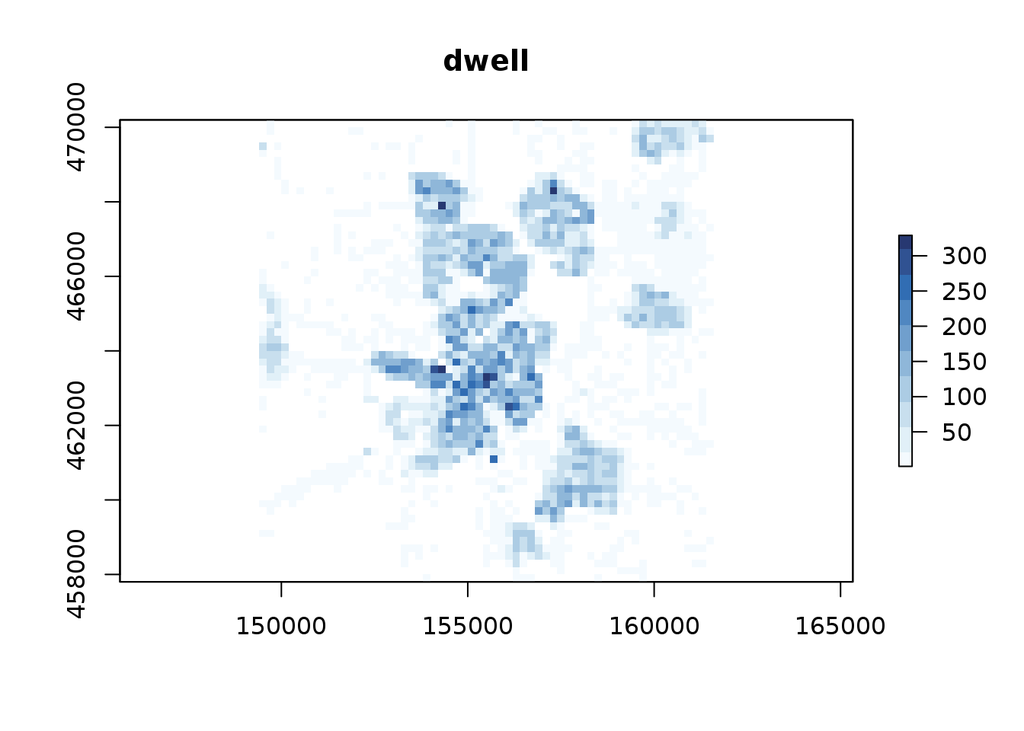

```r
plot(dwell, "count", sensitive = FALSE)
```

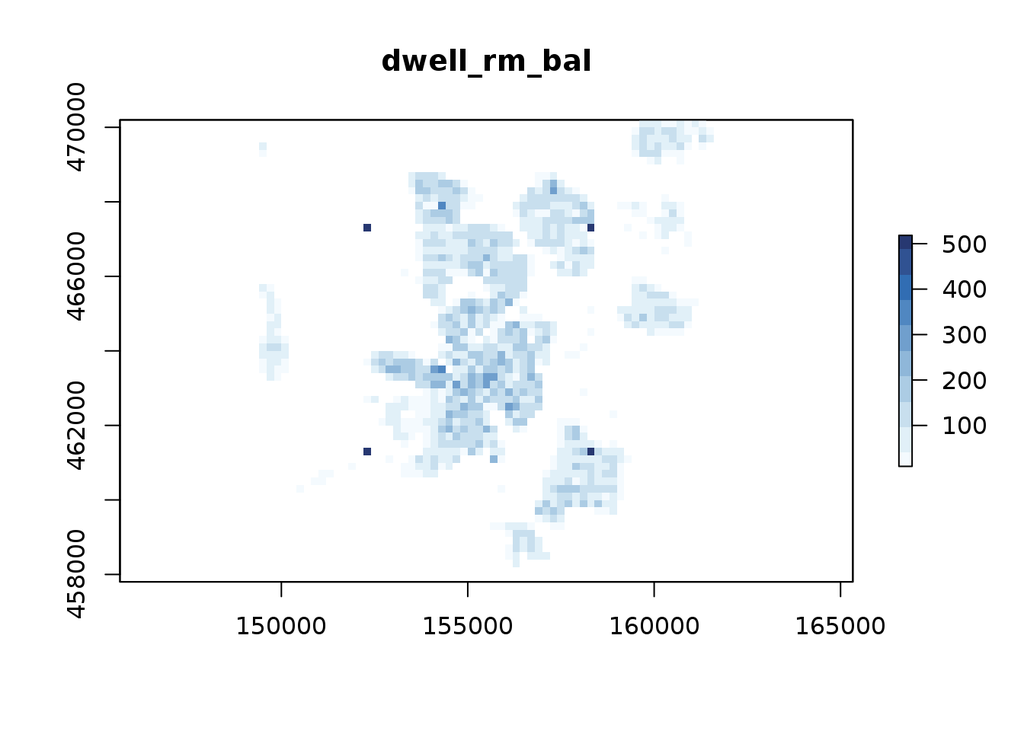

```r
plot(dwell_rm_bal, "count", sensitive = FALSE)
```

```r
kwd_rm_resc <- getKWD(dwell_rm$value$count, dwell$value$count)
```

```
## CompareOneToOne, Solution method: APPROX
## WARNING: the Xs input coordinates are not consecutives integers.
## WARNING: the Ys input coordinates are not consecutives integers.
## INFO: Recoding the input coordinates to consecutive integers.
## INFO: change <timelimit> to 14400.000000
## INFO: change <verbosity> to silent
## INFO: change <opt_tolerance> to 0.000001
```

```r
kwd_rm_bal  <- getKWD(dwell_rm_bal$value$count, dwell$value$count)
```

```
## CompareOneToOne, Solution method: APPROX
## WARNING: the Xs input coordinates are not consecutives integers.
## WARNING: the Ys input coordinates are not consecutives integers.
## INFO: Recoding the input coordinates to consecutive integers.
## INFO: change <timelimit> to 14400.000000
## INFO: change <verbosity> to silent
## INFO: change <opt_tolerance> to 0.000001
```

```r
kwd_rm <- c(kwd_rm_resc$distance, kwd_rm_bal$distance)
names(kwd_sm) <- c("removal (vanilla)", "removal (balanced)")
kwd_rm
```

```
## [1] 0.2378670 0.2736089
```